# Assignment 2

# `for` Loops & Functions

### 1. Monkey song

Consider the song [“5 little monkeys jumping on the bed”](https://en.wikipedia.org/wiki/Five_Little_Monkeys). It goes something like this:

```
5 little monkeys jumping on the bed,
One fell down and bumped his head,
Mama called the doctor and the doctor said,
"No more monkeys jumping on the bed!"
```

The same verse is repeated, each time with one monkey fewer, until there is one left:

```
1 little monkey jumping on the bed
He fell down and bumped his head
Mama called the doctor and the doctor said,
"No more monkeys jumping on the bed!".
```

The last verse following the last monkey going down is:

```
No little monkeys jumping on the bed,
None fell down and bumped their head,
Papa called the doctor and the doctor said,
"Put those monkeys right to bed!"
```

#### a) Write a loop

Write a `for` loop that will iterate the main verse from 5 to 1. End with the last verse.

Show the loop code and the print output in your solution. (Hint: the `cat()` or `paste()` function may be useful to concatenate the string output you want.)

#### b) Convert loop to a function

Now convert the loop into a function. Allow such that we can substitute “monkeys” for any type of animal and a different variable number of them (but assume the number of animals entered is larger or equal to 3). Set the default values of your function arguments to the original song. Show the function code in your solution and print the output using the following values: `3`, `elephant`.

#### c) Add error check

Add an error check to produce a warning when a user passes a non-numeric input to the number of animals.

### 2. Draw a plot using a loop

Let’s draw a plot with a loop. You can inialize a new plot with `plot()`. Lines can be added to a plot with `lines()` command. For example, `lines(x = c(1,1), y = c(1,7))` will draw a line between the coordinates `(1,1)` and `(1,7)`.

So, as an example to get you started:

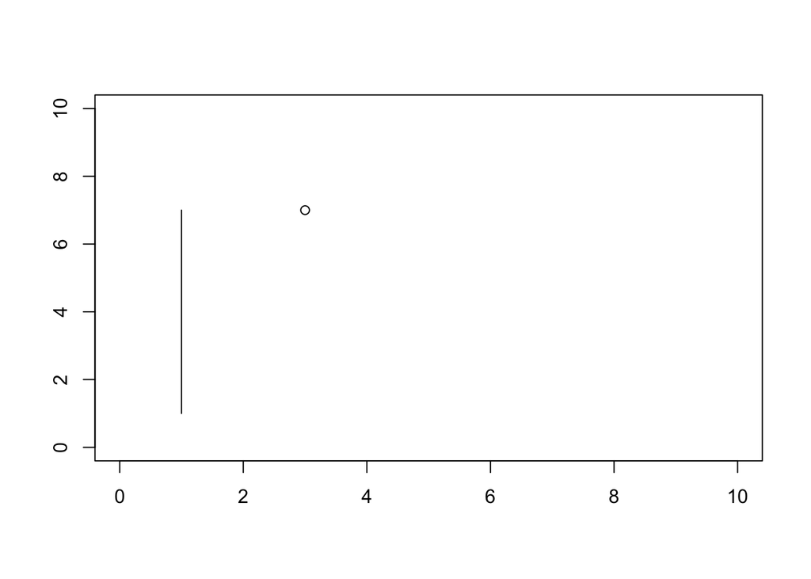

```r
plot(1, type="n", xlab="", ylab="", xlim = c(0, 10), ylim = c(0, 10)) # initialize an empty plot
lines(x = c(1,1), y = c(1,7)) # Add Lines to the plot
points(x = 3, y = 7) # Add points to the plot
```

#### a) Plot with horizontal lines

Initialize a plot. Add 11 horizontal lines (from 0 to 10) using a `for` loop. Show the code of the loop and the plot in the output.

Should look something like this:

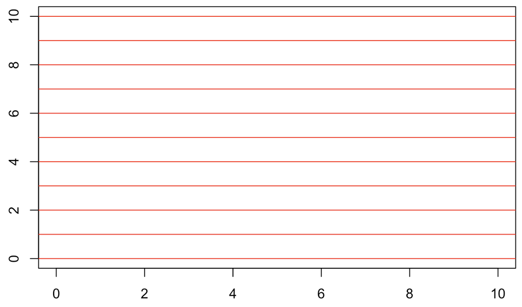

#### b) Add vertical lines

Extend the previous code, but now also add 11 vertical lines. Show the code and the changed plot in the output.

Should look something like this:

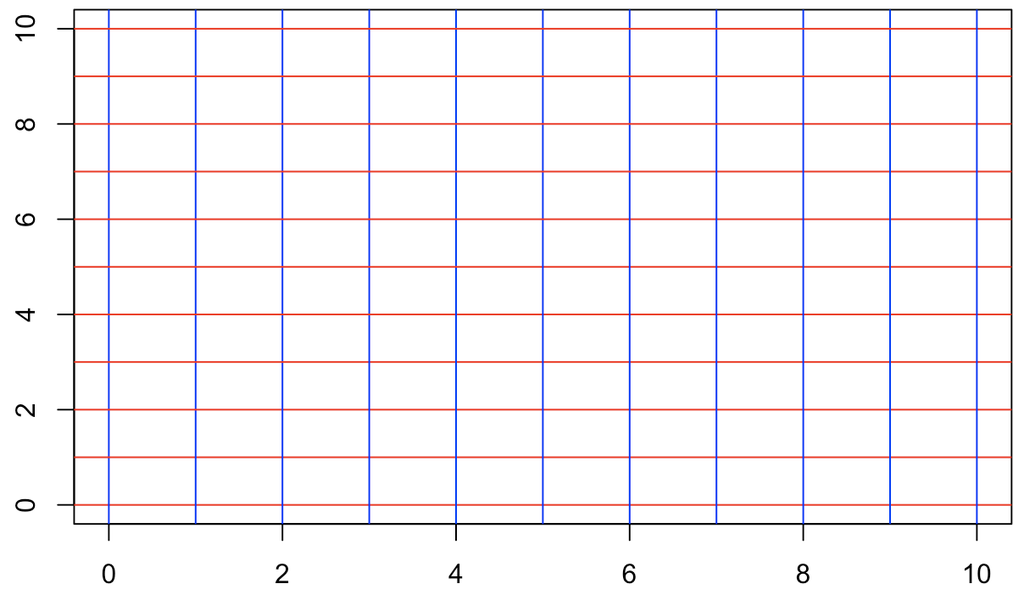

#### d) Convert to function

Convert this into a function that will allow the user to set the size of the plot (the plot should be square) and which items to draw (horizontal lines and vertical lines). Show the function you have written but no other output. Make sure the arguments of the function are set to sensible default values.

### 3. Descriptive Statistics of a Vector with Error Checks

Write a `desc_stats()` function that calculates some descriptive statistics for a vector.

#### a) Calculate min and max

Write a function that takes a vector as input and prints its minimum and maximum. Make sure to remove any `NA`s from the vector before the calculations.

#### b) Add the median

Add an additional argument to the function (set to `FALSE` by default) that will allow a user to calculate the median of the vector as well. If the median is calculated, round it to two digits (hint: use the function `round()`).

#### c) Add error checks

Try your function on an empty vector `z1 <- c()` and a vector containing only `NA`s. You probably get a rather cryptic error. Alter your function so that it stops when a user supplies an empty vector or a vector with only `NA`s and gives a short warning about the issue. I suggest to use the `return()` function for this as the first step of your function.